# Differential gene expression across patients

Continuing from the differential expression tutorial, we will now look more into detail into differential expression across conditions and the confounding patient effect.

We can first load the data from the clustering session. Moreover, we can already decide which clustering resolution to use. First let’s define using the `louvain` clustering to identifying differentially expressed genes.

```r
suppressPackageStartupMessages({
    library(Seurat)
    # library(venn)
    library(dplyr)
    library(cowplot)
    library(ggplot2)
    library(pheatmap)
    # library(rafalib)
})

alldata <- readRDS("data/results/covid_qc_dr_int_cl.rds")
```

```r
# Set the identity as louvain with resolution 0.5
sel.clust = "CCA_snn_res.0.5"

alldata <- SetIdent(alldata, value = sel.clust)
table(alldata@active.ident)
```

```
##
##    0    1    2    3    4    5    6    7    8    9
## 1508 1026  573  447  430  425  423  246  237  217
```

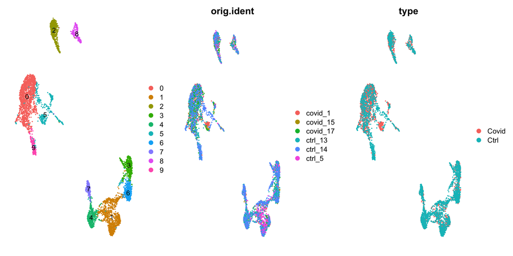

```r
# plot this clustering
plot_grid(ncol = 3, DimPlot(alldata, label = T) + NoAxes(), DimPlot(alldata, group.by = "orig.ident") +
    NoAxes(), DimPlot(alldata, group.by = "type") + NoAxes())
```

## Remove sex chromosome genes

Since we have uneven balance of male/female patients, exclude the sex chromosome genes.

```r
gene.info = read.csv("data/results/genes.table.csv")

sex.genes = gene.info$external_gene_name[gene.info$chromosome_name %in% c("X", "Y")]
keep.genes = setdiff(rownames(alldata@assays$RNA@counts), sex.genes)

alldata@active.assay = "RNA"
alldata = alldata[keep.genes, ]

# Normalize again
alldata = NormalizeData(alldata)
```

## Differential expression across conditions

The second way of computing differential expression is to answer which genes are differentially expressed within a cluster. For example, in our case we have libraries comming from patients and controls and we would like to know which genes are influenced the most in a particular cell type.

For this end, we will first subset our data for the desired cell cluster, then change the cell identities to the variable of comparison (which now in our case is the “type”, e.g. Covid/Ctrl).

```r
# select all cells in cluster 1
cell_selection <- subset(alldata, cells = colnames(alldata)[alldata@meta.data[, sel.clust] ==
    2])
cell_selection <- SetIdent(cell_selection, value = "type")
# Compute differentiall expression
DGE_cell_selection <- FindMarkers(cell_selection, ident.1 = "Covid", logfc.threshold = 0.2,
    test.use = "wilcox", min.pct = 0.1, min.diff.pct = 0.2, max.cells.per.ident = 50,
    assay = "RNA")

DGE_cell_selection$dir = ifelse(DGE_cell_selection$avg_log2FC > 0, "Covid", "Ctrl")
DGE_cell_selection$gene = rownames(DGE_cell_selection)
```

We can now plot the expression across the “type”.

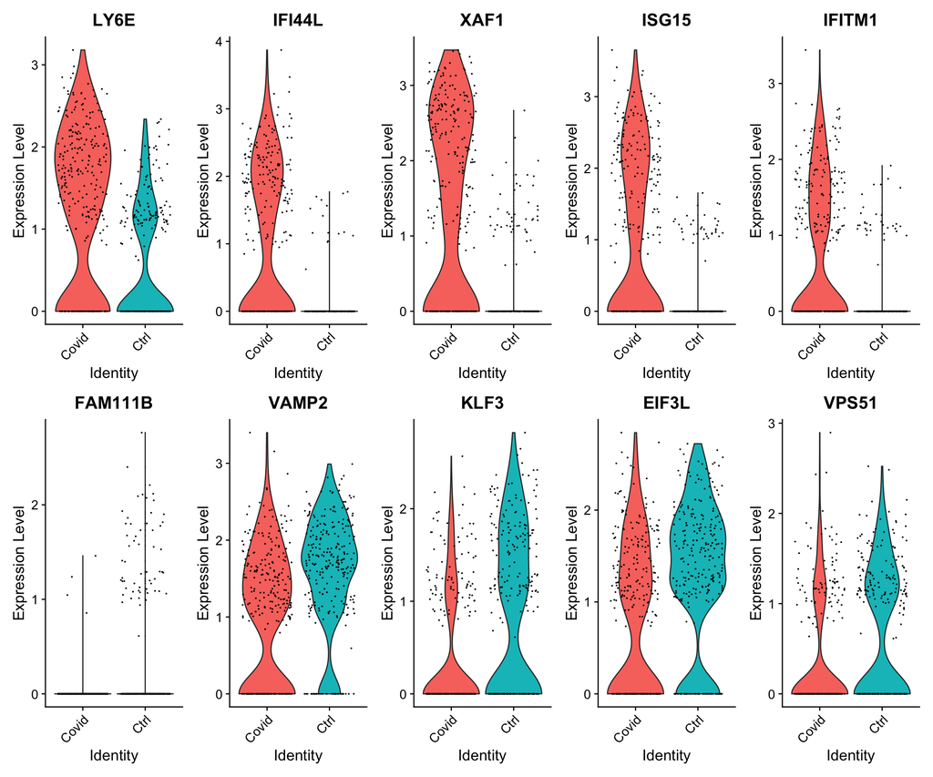

```r
DGE_cell_selection %>%
    group_by(dir) %>%
    top_n(-5, p_val) %>%
    arrange(dir) -> top5_cell_selection

VlnPlot(cell_selection, features = as.character(unique(top5_cell_selection$gene)),
    ncol = 5, group.by = "type", assay = "RNA", pt.size = 0.1)
```

Dotplot per patient within cluster2

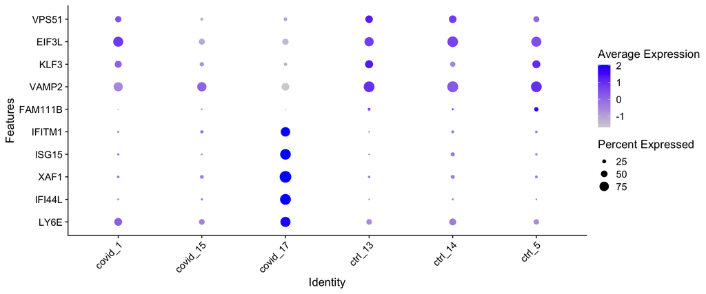

```r
DotPlot(cell_selection, features = as.character(unique(top5_cell_selection$gene)),
    group.by = "orig.ident", assay = "RNA") + RotatedAxis() + coord_flip()
```

As you can see, many of the genes that comes up as DE for Covid patients are dominated by the covid_17 patient and not found in the other 2.

## Cluster 2

Look in more detail at cluster1

```r
cell_selection = alldata[, alldata[[sel.clust]] == 2]

t1 = table(alldata$orig.ident)
t2 = table(cell_selection$orig.ident)
stats = data.frame(all = t1, cl2 = as.vector(t2), prop = as.vector(t2/t1 * 100))
stats
```

```
##   all.Var1 all.Freq cl2      prop
## 1  covid_1      837  91 10.872162
## 2 covid_15      540  38  7.037037
## 3 covid_17      976 173 17.725410
## 4  ctrl_13     1129  67  5.934455
## 5  ctrl_14     1028  63  6.128405
## 6   ctrl_5     1022 141 13.796477
```

```r
cell_selection <- SetIdent(cell_selection, value = "type")
```

Clearly cells from covid_17 and ctrl_5 are dominating cluster2.

## Subsample

As the distribution of samples is uneven in the cluster, some of the patient effect can be removed by subsampling to an equal number of cells per patient.

Subsample and rerun same DGE test.

```r
print(table(cell_selection$orig.ident))
```

```
##
##  covid_1 covid_15 covid_17  ctrl_13  ctrl_14   ctrl_5
##       91       38      173       67       63      141
```

```r
cell_selection <- SetIdent(cell_selection, value = "orig.ident")

sub_data <- subset(cell_selection, cells = WhichCells(cell_selection, downsample = 30))
```

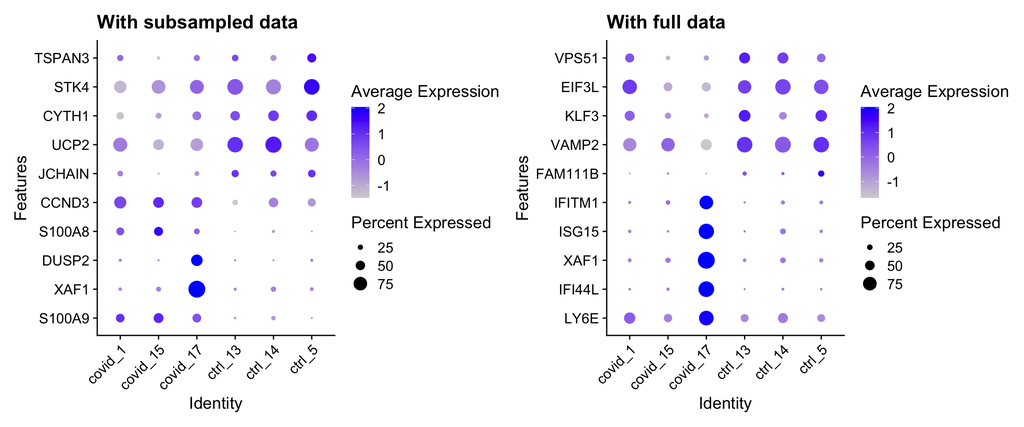

```r
sub_data <- SetIdent(sub_data, value = "type")

DGE_sub <- FindMarkers(sub_data, ident.1 = "Covid", logfc.threshold = 0.2, test.use = "wilcox",
    min.pct = 0.1, min.diff.pct = 0.2, max.cells.per.ident = 50, assay = "RNA")

DGE_sub$dir = ifelse(DGE_sub$avg_log2FC > 0, "Covid", "Ctrl")
DGE_sub$gene = rownames(DGE_sub)

DGE_sub %>%
    group_by(dir) %>%
    top_n(-5, p_val) %>%
    arrange(dir) -> top5_sub

p1 = DotPlot(cell_selection, features = as.character(unique(top5_sub$gene)), group.by = "orig.ident",
    assay = "RNA") + coord_flip() + ggtitle("With subsampled data") + RotatedAxis()

p2 = DotPlot(cell_selection, features = as.character(unique(top5_cell_selection$gene)),
    group.by = "orig.ident", assay = "RNA") + coord_flip() + ggtitle("With full data") +
    RotatedAxis()

p1 + p2
```

Still have some patient specific genes, but less dominance of covid_17.

## Pseudobulk

One option is to treat the samples as pseudobulks and do differential expression for the 3 patients vs 3 controls. You do lose some information about cell variability within each patient, but instead you gain the advantage of mainly looking for effects that are seen in multiple patients.

However, having only 3 patients is probably too low, with many more patients it will work better to run pseudobulk analysis.

For a fair comparison we should have equal number of cells per sample, so we will use the subsampled object.

```r
library(Matrix)
library(edgeR)

table(sub_data$orig.ident)
```

```
##
##  covid_1 covid_15 covid_17  ctrl_13  ctrl_14   ctrl_5
##       30       30       30       30       30       30
```

```r
DGE_DATA <- sub_data@assays$RNA@counts

# Compute pseudobulk
mm <- sparse.model.matrix(~0 + sub_data$orig.ident)
pseudobulk <- DGE_DATA %*% mm

bulk.labels = c("Covid", "Covid", "Covid", "Ctrl", "Ctrl", "Ctrl")

dge.list <- DGEList(counts = pseudobulk, group = factor(bulk.labels))
keep <- filterByExpr(dge.list)
dge.list <- dge.list[keep, , keep.lib.sizes = FALSE]

dge.list <- calcNormFactors(dge.list)
design = model.matrix(~bulk.labels)

dge.list <- estimateDisp(dge.list, design)

fit <- glmQLFit(dge.list, design)
qlf <- glmQLFTest(fit, coef = 2)
topTags(qlf)
```

```
## Coefficient:  bulk.labelsCtrl
##            logFC    logCPM        F       PValue          FDR
## S100A9 -3.930667  8.014340 94.68516 3.106390e-08 5.305714e-05
## S100A8 -4.449281  7.463980 60.65120 6.514724e-07 5.563575e-04
## IGHA1  -3.474005  6.407754 22.40593 2.089590e-04 1.189673e-01
## CD69   -2.138357 10.809845 18.66698 4.969372e-04 2.121922e-01
## CCND3  -1.185906  7.856013 15.01097 1.283555e-03 4.384624e-01
## AREG   -1.866897  6.519806 13.78853 1.811439e-03 5.156563e-01
## RELB    1.493754  6.968735 11.85117 3.232325e-03 6.071777e-01
## AHNAK   1.092197  7.964648 11.76592 3.319131e-03 6.071777e-01
## KDM6B  -1.563079  7.662743 11.50711 3.599244e-03 6.071777e-01
## NFKBIA -1.219490 10.561015 11.04399 4.169781e-03 6.071777e-01
```

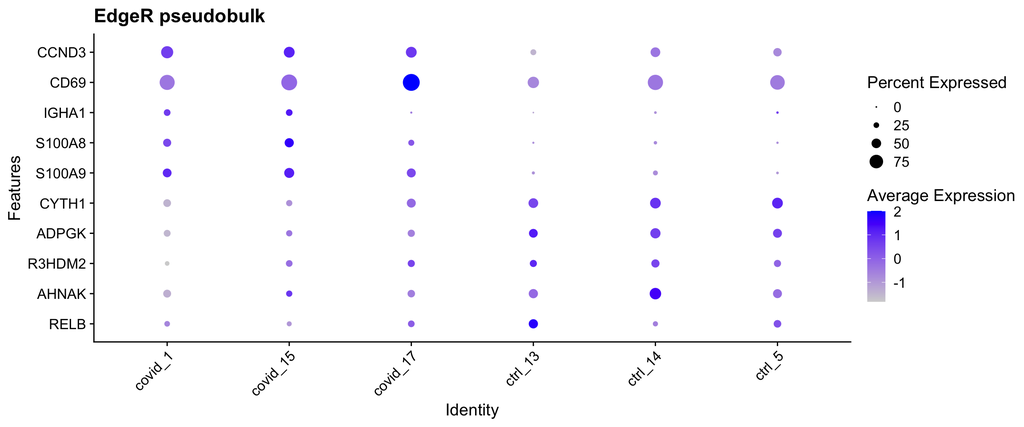

```r
res.edgeR <- topTags(qlf, 100)$table
res.edgeR$dir = ifelse(res.edgeR$logFC > 0, "Covid", "Ctrl")
res.edgeR$gene = rownames(res.edgeR)

res.edgeR %>%
    group_by(dir) %>%
    top_n(-5, PValue) %>%
    arrange(dir) -> top.edgeR



DotPlot(cell_selection, features = as.character(unique(top.edgeR$gene)), group.by = "orig.ident",
    assay = "RNA") + coord_flip() + ggtitle("EdgeR pseudobulk") + RotatedAxis()
```

# MAST with random effect

MAST has the option to add a random effect for the patient when running DGE analysis. It works quite well but is very slow, even with this small dataset, so it may not be practical for a larger dataset.

We will run MAST with and without patient info as random effect and compare the results

First, filter genes a bit to only have genes expressed in at least one of the groups for speed.

```r
nE_covid = rowSums(cell_selection@assays$RNA@counts[, cell_selection$type == "Covid"] >
    0)
nE_ctrl = rowSums(cell_selection@assays$RNA@counts[, cell_selection$type == "Ctrl"] >
    0)

# require expression in at least 10 cells from one of the group

sel = nE_covid >= 10 | nE_ctrl >= 10

cell_selection = cell_selection[sel, ]
```

Setup the MAST object.

```r
library(MAST)

fData <- data.frame(primerid = rownames(cell_selection))

m = cell_selection@meta.data
m$wellKey = rownames(m)

# make sure type and orig.ident are factors
m$orig.ident = factor(m$orig.ident)
m$type = factor(m$type)

sca <- MAST::FromMatrix(exprsArray = as.matrix(x = cell_selection@assays$RNA@data),
    check_sanity = FALSE, cData = m, fData = fData)
```

Run regular MAST with bayesglm

```r
# takes a while to run, save to tmpdir
tmpdir = "tmp_dge"
dir.create(tmpdir, showWarnings = F)

tmpfile1 = file.path(tmpdir, "mast_bayesglm_cl1.Rds")
if (file.exists(tmpfile1)) {
    fcHurdle1 = readRDS(tmpfile1)
} else {
    zlmCond <- suppressMessages(MAST::zlm(~type, sca, method = "bayesglm", ebayes = T))

    summaryCond <- suppressMessages(MAST::summary(zlmCond, doLRT = "typeCtrl"))
    summaryDt <- summaryCond$datatable
    fcHurdle <- merge(summaryDt[summaryDt$contrast == "typeCtrl" & summaryDt$component ==
        "logFC", c(1, 7, 5, 6, 8)], summaryDt[summaryDt$contrast == "typeCtrl" &
        summaryDt$component == "H", c(1, 4)], by = "primerid")
    fcHurdle1 <- stats::na.omit(as.data.frame(fcHurdle))
    saveRDS(fcHurdle1, tmpfile1)
}
```

Run with glmer and random effect.

```r
library(lme4)

tmpfile2 = file.path(tmpdir, "mast_glme_cl1.Rds")
if (file.exists(tmpfile2)) {
    fcHurdle2 = readRDS(tmpfile2)
} else {
    zlmCond <- suppressMessages(MAST::zlm(~type + (1 | orig.ident), sca, method = "glmer",
        ebayes = F, strictConvergence = FALSE))

    summaryCond <- suppressMessages(MAST::summary(zlmCond, doLRT = "typeCtrl"))
    summaryDt <- summaryCond$datatable
    fcHurdle <- merge(summaryDt[summaryDt$contrast == "typeCtrl" & summaryDt$component ==
        "logFC", c(1, 7, 5, 6, 8)], summaryDt[summaryDt$contrast == "typeCtrl" &
        summaryDt$component == "H", c(1, 4)], by = "primerid")
    fcHurdle2 <- stats::na.omit(as.data.frame(fcHurdle))
    saveRDS(fcHurdle2, tmpfile2)
}
```

Top genes with normal:

```r
top1 = head(fcHurdle1[order(fcHurdle1$`Pr(>Chisq)`), ], 10)
top1
```

```
##      primerid       coef      ci.hi      ci.lo          z   Pr(>Chisq)
## 3075 HLA-DRB5 -0.7355489 -0.5607038 -0.9103940  -8.245295 2.334949e-50
## 5981    RPS26  1.2151374  1.3727629  1.0575119  15.109392 4.776932e-48
## 1306     CD74  0.4996651  0.5606801  0.4386500  16.050560 2.842767e-46
## 7902     XAF1 -1.1943997 -1.0407559 -1.3480436 -15.236404 1.878491e-44
## 3205   IFI44L -0.9996539 -0.8717709 -1.1275369 -15.320925 5.119676e-43
## 1303     CD69 -1.2963660 -1.1097949 -1.4829371 -13.618566 3.667890e-42
## 3355    ISG15 -0.9372127 -0.8007170 -1.0737083 -13.457594 1.331758e-36
## 3071 HLA-DQA2 -0.8439978 -0.7091228 -0.9788728 -12.264728 4.672496e-31
## 3356    ISG20 -0.8172102 -0.6700465 -0.9643738 -10.883820 1.337161e-30
## 4530   NFKBIA -0.7189137 -0.5712524 -0.8665750  -9.542410 1.973669e-29
```

```r
fcHurdle1$pval = fcHurdle1$`Pr(>Chisq)`
fcHurdle1$dir = ifelse(fcHurdle1$z > 0, "up", "down")
fcHurdle1 %>%
    group_by(dir) %>%
    top_n(-5, pval) %>%
    arrange(z) -> mastN

mastN = mastN$primerid
```

Top genes with random effect:

```r
top2 = head(fcHurdle2[order(fcHurdle2$`Pr(>Chisq)`), ], 10)
top2
```

```
##        primerid        coef      ci.hi       ci.lo          z   Pr(>Chisq)
## 6069     S100A9 -0.59010366 -0.4777773 -0.70243004 -10.296619 6.672089e-05
## 3073    HLA-DRA  0.36845935  0.4656461  0.27127259   7.430714 6.854451e-05
## 3069   HLA-DPB1  0.36127643  0.4663603  0.25619257   6.738321 8.623899e-05
## 6068     S100A8 -0.51587007 -0.3477585 -0.68398159  -6.014381 1.008301e-04
## 5009    PHACTR1 -0.48449101 -0.3499435 -0.61903853  -7.057618 1.671298e-04
## 6251        SF1  0.52155357  0.7746346  0.26847253   4.039126 1.764146e-04
## 4886      PCBP2  0.28799845  0.4113277  0.16466921   4.576908 2.531350e-04
## 3399     JCHAIN  0.27728722  0.3928919  0.16168258   4.701134 4.152055e-04
## 185  AC139887.2  0.08003611  0.1292577  0.03081454   3.186975 6.965247e-04
## 2932      GUCD1  0.22600159  0.3327811  0.11922209   4.148315 8.225920e-04
```

```r
fcHurdle2$pval = fcHurdle2$`Pr(>Chisq)`
fcHurdle2$dir = ifelse(fcHurdle2$z > 0, "up", "down")
fcHurdle2 %>%
    group_by(dir) %>%
    top_n(-5, pval) %>%
    arrange(z) -> mastR

mastR = mastR$primerid
```

Plot

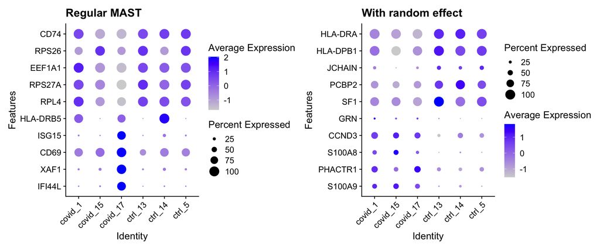

```r
p1 = DotPlot(cell_selection, features = mastN, group.by = "orig.ident", assay = "RNA") +
    coord_flip() + RotatedAxis() + ggtitle("Regular MAST")

p2 = DotPlot(cell_selection, features = mastR, group.by = "orig.ident", assay = "RNA") +
    coord_flip() + RotatedAxis() + ggtitle("With random effect")


p1 + p2
```

## Refs

More on this topic can be found in these papers:

Muscat paper: https://www.nature.com/articles/s41467-020-19894-4

Covid paper (diffxpy): https://www.nature.com/articles/s41591-020-01227-z

Muscat also has many different methods for differential expression in patient samples, see their tutorial at: https://bioconductor.org/packages/release/bioc/vignettes/muscat/inst/doc/analysis.html